# Theoretical foundations

In this section, the theoretical underpinnings for the subject of the thesis will be explained.

## Financial risk measurement and measures

In this section, a quick review of both VaR and ES is given. ES builds on VaR, and it is therefore necessary to provide the foundation for VaR as well.

### Introduction

In general terms, a risk measure maps a financial position with loss $L$ with a real number measuring the “riskiness” of $L$. Risk measures are used for a range of different purposes in practice. Among other things, they are used to determine the amount of capital a financial institution needs to maintain to guard against future losses (expected and unexpected) on its portfolio, in order to satisfy regulators. They can also be used to determine appropriate margin requirements for investors engaged in trading.

The approaches to measuring risk of a financial position can be grouped into three categories: the *notional-amount* approach, risk measures based on *loss distributions* and risk measures based on *scenarios*.

The notional-amount approach is the earliest approach to quantifying the risk of a portfolio of risky assets. In this approach, the risk of a portfolio is defined as the sum of the notional values of the individual securities in the portfolio, which are then weighted by some factor taken to represent an assessment of the riskiness of each constituent part of the portfolio. Scenario-based risk measures considers a range of different future risk-factor changes – scenarios – such as an increase in relevant exchange rates with a concurrent drop in major stock indices. Using the scenario-based approach, the risk of a portfolio is measured as the maximum loss of the portfolio under *all* scenarios. This approach is the one generally adopted in so-called stress testing. Finally, risk measures based on loss distributions constitute statistical quantities describing the conditional or unconditional loss distribution of a portfolio over some predetermined time horizon $\Delta t$. This is the approach used in most modern measures, VaR and ES being two examples. For this reason, it will be the focus for this thesis. The interested reader can consult @crouhy2000comparative, which gives an extensive overview of different approaches to risk quantification.

### Risk measures based on loss distributions

Let $V_{t+1}$ represent the value of a portfolio at the end of a certain time period and let $\Delta V_{t+1} = V_{t+1} - V_t$ represent the change in the value of that portfolio. The *loss* is then defined as $L_{t+1} := -\Delta V_{t+1}$. The distribution of $L_{t + 1}$ is what is termed the *loss distribution*.

Risk measures based on loss distributions have a number of advantages. The concept of a loss distribution is sensible on all levels of aggregation, i.e. from a single financial instrument to the overall position of a financial institution. Furthermore, the loss distribution reflects netting and diversification effects (@mcneil2015quantitative).

#### Value-at-Risk (VaR)

As stated in the introduction, VaR is the most widely used risk measure in financial institutions and it has had a prominent role in the Basel regulatory. Let us consider a portfolio of risky assets and a fixed time horizon $\Delta t$, with the distribution function of the corresponding loss distribution be denoted by $F_{L}(l)=P(L \leq l)$. The idea behind VaR is to define a statistic based on $F_L$ that measures the severity of the risk of holding a portfolio over the time period $\Delta t$. In general terms, VaR is then defined as the maximum loss that is not exceed with a given high probability. A more formal definition is as follows (@mcneil2015quantitative).

```
Given som confidence level $\alpha \in (0,1)$ the VaR of a portfolio with loss $L$ at the confidence level $\alpha$ is given by the smallest number $l$ such that the probability that the loss $L$ exceeds $l$ is no larger than $1-\alpha$.

\begin{equation}
\text{VaR}_{\alpha} = \text{inf}\{l \in \mathbb R: P(L > l) \leq 1 - \alpha \} = \text{inf}\{l \in \mathbb R: F_{L}(l) \geq \alpha \}.
(\#eq:VaR)
\end{equation}
```

In general, VaR is defined as the opposite of the minimum loss that can occur at a given (high) confidence level for a pre-defined time horizon. The regulatory norms for market risk set the time horizon at 10 days, indicating the period in which a bank is supposed to be able to liquidate the relevant position, and the confidence level at 99% (@rocco2013).

#### Expected Shortfall (ES)

ES is defined as the conditional expectation of loss for losses beyond the VaR level. Thus, by definition, ES takes into account losses beyond the VaR level. Therefore, while VaR represents the *minimum* loss expected at a determined confidence level, ES represents the expected *value* of that loss, provided that the loss is equal to or greater than the VaR (@zikovic2012ranking).

ES at the confidence level $\alpha$ is defined as the average of the VaRs which are greater than $\text{VaR}_\alpha$, that is

$$\begin{equation}
\text{ES}_{\alpha}(X) = \frac{1}{1-\alpha} \int_{\alpha}^{1} \text{VaR}_{z}(X)\text{dz}.
(\#eq:ES)
\end{equation}$$

By the definition in @ref(eq:ES), at the confidence level $\alpha$, ES takes into account what occurs in the tail, beyond the corresponding $\text{VaR}_{\alpha}$. @acerbi2001expected and @acerbi2002coherence has shown that ES is convex, making it suitable as a candidate for a sensible risk measure.

## The theory of extreme values

### Introduction

Extreme value theory (EVT) is a branch of probability that is concerned with limiting laws for extreme values in large samples. EVT contains many important results describing the behaviour of sample maxima and minima, upper-order statistics and sample values exceeding high thresholds. EVT has many applications, but the focus of this thesis will be its application on financial risk factors, and in particular in modeling the extremal behaviour of such risk factors. More specifically, the interest is on models for the *tail* of the distribution of financial risk-factor changes.

Following @mcneil1999extreme, there are two main methods for estimating extreme values. The first method consists of so-called *block maxima* (BM) models, which are centered around the generalized extreme value (GEV) distribution and based on the Fisher-Tippett-Gnedenko theorem. Block maxima models represent models that are designed for the largest observations from samples of i.i.d. observations. The second method consists of *peaks-over-threshold* (POT) models, which are centered around the generalized Pareto distribution (GPD) and based on the Pickands-Balkema-de Haan theorem. These models concern all observations which exceed a certain (high) threshold. Within the class of models using POT, there is a choice between a fully parametric approach based on the GPD and a semi-parametric approach centered around the so-called Hill estimator. POT models are generally considered more efficient in modeling limited data sets, as they are not as reliant on large data sets as BM models and thus not as wasteful of data, see @gilli2006 and @mcneil2015quantitative. Since extreme data is generally scarce, block maxima models have been largely superseded in practice by methods based on POT models, which instead uses all the data that exceed a particular designated high threshold. For this reason, the POT method will be used in this thesis. A short introduction to the general theory behind both BM and POT models are given in the following sections, which are mainly adapted from @embrechts1997modelling and @mcneil2015quantitative.

### Block maxima-based models

Consider a sequence of independently and identically distributed random variables $(X_i)_{i \in \mathbb N}$, here representing financial losses such as operational losses, insurance losses and losses on a credit portfolio over fixed time intervals.

In EVT, the *generalized extreme value (GEV) distribution* has a role analogous to that of the normal distribution in the central limit theory for sums of random variables.

In classical EVT, we are concerned with limiting distributions for normalized maxima. Denote the maximum of $n$ independently and identically distributed random variables $X_1, X_2, \dots,X_n$ by $M_n = \text{max}\{X_1,X_2,\dots X_n\}$ (also referred to as an $n$-block maximum). Then, the only possible non-degenerate[^1] limiting distributions for normalized maxima as $n \rightarrow \infty$ are in the GEV family.

```
The df of the standard GEV distribution is given by

\begin{equation}
H_{\xi}(x) =
\begin{cases}
\text{exp}(-(1 +\xi x)^{-1/\xi}) , &  \xi \ \neq\ 0, \\
\text{exp}(-e^{-x}), & \xi \ =\ 0, \\
\end{cases}
(\#eq:gev)
\end{equation}
```

where $1 + \xi x > 0$. A three-parameter family is obtained by defining $H_{\xi, \mu, \sigma}(x):= H_{\xi}((x-\mu)/\sigma)$ for a location parameter $\mu \in \mathbb R$ and a scale parameter $\sigma > 0$.

The parameter $\xi$ is called the *shape* parameter of the GEV distribution, and $H_\xi$ defines a *type* of distribution, i.e. a family of distributions specified up to location and scaling. The extreme value distribution in Definition @ref(def:gev) is generalized in the sense that the parametric form subsumes three types of distributions that are known by other names according to the value of $\xi$, namely:

**The Fréchet distribution** when $\xi > 0$, with CDF

$$\begin{equation}
H_{\xi}(x) =
\begin{cases}
\text{exp} [ -(1 + \xi(\frac{x-\mu}{\sigma})^{-1/\xi}], & \text{if}\ x \ >\ -1/\xi, \\
0, & \text{otherwise}.
\end{cases}
(\#eq:Frechet)
\end{equation}$$

**The Gumbel distribution** when $\xi = 0$, with CDF

$$\begin{equation}
H_{\xi}(x) = \text{exp}[-\text{exp}(-(\frac{x-\mu}{\sigma}))], \quad -\infty < x < \infty.
(\#eq:Gumbel)
\end{equation}$$

**The Weibull distribution** when $\xi < 0$, with CDF

$$\begin{equation}
H_{\xi}(x) =
\begin{cases}
\text{exp}[-(1+\xi(\frac{x-\mu}{\sigma}))^{-1\xi}] , & \text{if}\ x \ <\ -1/\xi, \\
0, & \text{otherwise}.
\end{cases}
(\#eq:Weibull)
\end{equation}$$

The distribution function and density of the GEV distribution are shown in Figure @ref(fig:gevDist) for the three cases above.

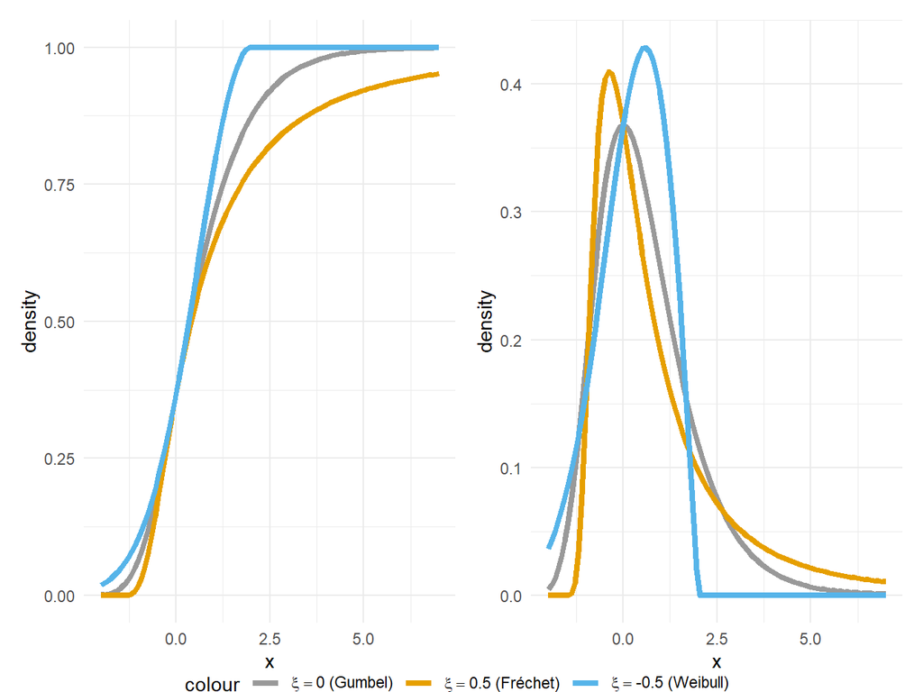

The df (left) and density (right) of a standard GEV distribution in three cases, corresponding to the Gumbel, Fréchet and Weibull distributions, respectively.

Now, supposing that the maxima $M_n$ of independently and identically distributed random variables converge in distribution as $n \rightarrow \infty$ under an appropriate normalization. Having that $P(M_n \leq x) = F^{n}(x)$, this convergence means that there exists sequences of real constants $d_n$ and $c_n$ where $c_n > 0$ for all $n$ such that

$$\begin{equation}
\lim_{n \to \infty} P((M_n - d_n)/c_n \leq x) = \lim_{n \to \infty} F^{n}(c_{n}x + d_n) = H(x),
(\#eq:limitingdist)
\end{equation}$$

for some non-degenerate distribution function $H(x)$. The role of the GEV distribution in the study of maxima is formalized by the following definition and theorem.

```
If Equation \@ref(eq:limitingdist) holds for some non-degenerate distribution function $H$, then $F$ is said to be in the maximum domain of attraction of $H$, written $F \in \text{MDA}(H)$.
```

```
If $F \in \text{MDA}(H)$ for some non-degenerate distribution function $H$, then $H$ must be a distribution of type $H_{\xi}$, i.e. a GEV distribution.
```

### Peaks-over-threshold-based models

As was mentioned in the introduction to this section, the block maxima method has the major defect of being very wasteful of valuable data since it only retains the maximum losses in large blocks. In contrast, methods based on so-called threshold exceedances uses all data that exceed a particular threshold. The main distribution model for such exceedances over thresholds is the generalized Pareto distribution (GPD), which is introduced next.

For a random quantity $X$ with distribution function $F(x)$, @pickands1975statistical has shown that under certain conditions, $F(x \vert u) = P(X \leq u +x\vert X>u)$ can be approximated by a GPD, which is defined as follows (@mcneil2015quantitative).

```
The distribution function of the GPD is given by

\begin{equation}
G_{\xi, \beta}(x) =
\begin{cases}
1 - (1 + \xi x / \beta)^{-1/\xi}, & \text{if}\ \xi \ \neq\ 0 \\
1 - \exp(-x\beta), & \text{if}\ \xi \ =\ 0,
\end{cases}
(\#eq:GPD)
\end{equation}
```

Like the GEV distribution defined in Definition @ref(def:gev), the GPD is generalized in the sense that it contains a number of special cases: when $\xi > 0$ the distribution function $G_{\xi, \beta}$ is that of an ordinary Pareto distribution with $\alpha = 1/\xi$. When $\xi = 0$, we have an exponential distribution and when $\xi < 0$ we have a short-tailed Pareto type II distribution. Figure @ref(fig:gpdDist) shows the GPD distribution function and density for these three different cases

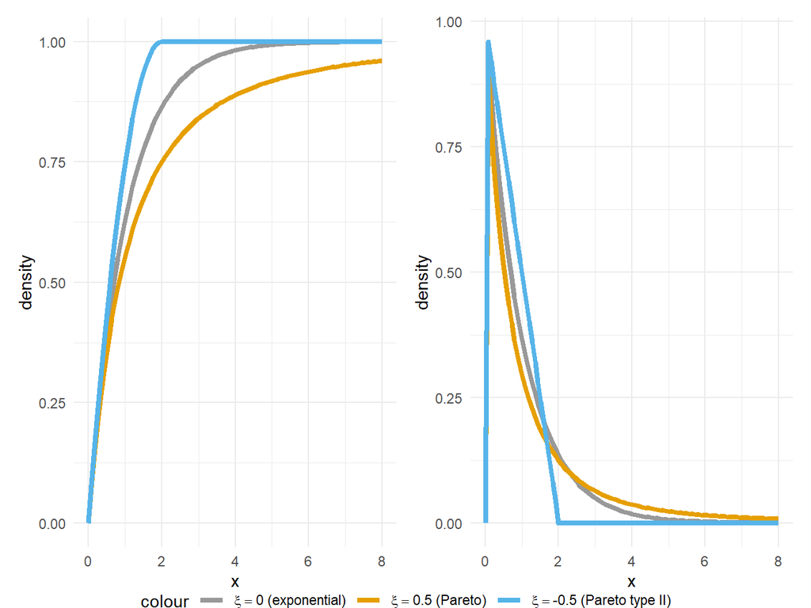

The df (left) and density (right) of a standard GPD distribution in three cases, corresponding to the exponential, Pareto and Pareto type II distributions, respectively.

The role of the GPD in EVT is as a natural model for the so-called *excess distribution* over a high threshold, which is defined as follows.

```
Let $X$ be a random variable with distribution function $F$. The excess distribution over the threshold $u$ has distribution function

\begin{equation}
F_{u}(x) = P(X - u \leq x \vert X > u) = \frac{F(x + u) - F(u)}{1 - F(u)},
(\#eq:excessdist)
\end{equation}

for $0 \leq x \leq x_F - u$, where $x_F \leq \infty$ is the right endpoint of $F$.
```

A related concept that also plays an important role in EVT is that of the *mean excess function*, which has the following definition.

```
The mean excess function of a random variable $X$ with finite mean is given by

\begin{equation}
e(u) = E(X - u \vert X > u).
(\#eq:meanexcess)
\end{equation}
```

The excess distribution function $F_u$ describes the distribution of the excess loss over the threshold $u$, given that $u$ is exceeded. The mean excess function $e(u)$ expresses the mean of $F_u$ as a function of $u$. In general, if X has distribution function $F = G_{\xi, \beta}$, then, following Equation @ref(eq:excessdist), the excess distribution function is

$$\begin{equation}
F_{u}(x) = G_{\xi, \beta (u)}(x), \quad \beta (u) = \beta + \xi u,
(\#eq:excessdistGPD)
\end{equation}$$

where $0 \leq x < \infty$ if $\xi \geq 0$ and $0 \leq x \leq -(\beta / \xi) - u$ if $\xi < 0$. Using Equation @ref(eq:excessdistGPD) and the mean of the GPD, which is $E(X) = \beta / (1-\xi)$, the mean excess function of the GPD is found to be

$$\begin{equation}
e(u) = \frac{\beta (u)}{1 - \xi} = \frac{\beta + \xi u}{1 - \xi},
(\#eq:meanexcessGPD)
\end{equation}$$

where $0 \leq u < \infty$ if $0 \leq \xi < 1$ and $0 \leq u \leq -\beta / \xi$ if $\xi < 0$. The mean excess function is linear in the threshold $u$, which is one of the characterizing properties of the GPD.

The following theorem shows that the GPD is a natural limiting excess distribution for many underlying loss distributions.

```
We can find a (positive-measurable function) $\beta (u)$ such that

\begin{equation}
\lim_{u \to x_F} \sup_{0 \leq x < x_{F-u}} \vert F_{u}(x) - G_{\xi, \beta (u)} (x) \vert = 0,
(\#eq:pickands)
\end{equation}

if and only if $F \in \text{MDA} (H_{\xi}), \xi \in \mathbb R$
```

Theorem @ref(thm:pickands) is a very widely applicable result that essentially shows that the GPD is the *canonical distribution* for modeling excess losses over high thresholds. It underlies modeling based on the GPD and the ideas behind the theorem can be found in @10.2307/2959306 and @pickands1975statistical.

### Modeling extremes

@mcneil2000estimation has proposed a two-step VaR forecasting method based on EVT, through which they use GARCH modeling to model, in the first step, the current market volatility background. The market volatility background is then, in the second step, fed into the VaR estimates as obtained from the POT model fitted to the residuals of a GARCH model.

[^1]: By a non-degenerate df is meant a distribution that is not concentrated on a single point.